# The Project

1. This is a project with minimal scaffolding. Expect to use the the discussion forums to gain insights! It’s not cheating to ask others for opinions or perspectives!
2. Be inquisitive, try out new things.
3. Use the previous modules for insights into how to complete the functions! You'll have to combine Pillow, OpenCV, and Pytesseract
4. There are hints provided in Coursera, feel free to explore the hints if needed. Each hint provide progressively more details on how to solve the issue. This project is intended to be comprehensive and difficult if you do it without the hints.

### The Assignment

Take a ZIP file) of images and process them, using a [library built into python](https://docs.python.org/3/library/zipfile.html) that you need to learn how to use. A ZIP file takes several different files and compresses them, thus saving space, into one single file. The files in the ZIP file we provide are newspaper images (like you saw in week 3). Your task is to write python code which allows one to search through the images looking for the occurrences of keywords and faces. E.g. if you search for "pizza" it will return a contact sheet of all of the faces which were located on the newspaper page which mentions "pizza". This will test your ability to learn a new ([library](https://docs.python.org/3/library/zipfile.html)), your ability to use OpenCV to detect faces, your ability to use tesseract to do optical character recognition, and your ability to use PIL to composite images together into contact sheets.

Each page of the newspapers is saved as a single PNG image in a file called images.zip. These newspapers are in english, and contain a variety of stories, advertisements and images. Note: This file is fairly large (~200 MB) and may take some time to work with, I would encourage you to use small_img.zip for testing.

Here's an example of the output expected. Using the small_img.zip file, if I search for the string "Christopher" I should see the following image:

[figure not shown]

If I were to use the images.zip file and search for "Mark" I should see the following image (note that there are times when there are no faces on a page, but a word is found!):

[figure not shown]

Note: That big file can take some time to process - for me it took nearly ten minutes! Use the small one for testing.

```python
import zipfile

from PIL import Image
import pytesseract
import cv2 as cv
import numpy as np

# loading the face detection classifier
face_cascade = cv.CascadeClassifier('readonly/haarcascade_frontalface_default.xml')

# the rest is up to you!
```

```python
def imageReadText(img):
    return pytesseract.image_to_string(img).lower().split()
```

```python
def faceFinder(img_path, full_image):
    img = cv.imread(img_path)

    gray = cv.cvtColor(img, cv.COLOR_BGR2GRAY)
    faces = face_cascade.detectMultiScale(gray, 1.35)

    return_list = []

    for face in faces:
        tup = (face[0],face[1],face[0]+face[2], face[1]+face[3])
        cropped = full_image.crop(tup)
        cropped.thumbnail((200,200))
        return_list.append(cropped)

    print("OpenCV found {} potential images".format(len(return_list)))
    return return_list
```

```python
def contactSheetConstructor(img_lst):
    import math

    first_image=img_lst[0]
    contact_sheet=Image.new(first_image.mode, (1000, 200 * math.ceil(len(img_lst)/5)))

    x=0
    y=0
    for img in img_lst:
        contact_sheet.paste(img, (x, y))
        if x+200 == contact_sheet.width:
            x=0
            y=y+200
        else:
            x=x+200

    return contact_sheet
```

```python
Image_list = []

print("Creating zip instance...")
zip = zipfile.ZipFile('readonly/images.zip')
print("Zip instance created. Loading image files...")

for i in zip.infolist():


    print("Opening file {}...".format(i.filename))
    image_full = Image.open(zip.open(i))

    print("Creating dictionary for file {}...".format(i.filename))
    img_dict = {'name':i.filename}

    print("Searching file {} for text...".format(i.filename))
    img_dict['text'] = imageReadText(image_full)

    print("Text loading complete. Searching file {} for images...".format(i.filename))
    img_dict['faces'] = faceFinder(zip.extract(i), image_full)

    print("Face search complete. Inserting results for file {} into the dictionary...".format(i.filename))
    Image_list.append(img_dict)

    print("Continuing to next file...")

print("Loading complete. Closing zip file.")
zip.close()
```

```
Creating zip instance...
Zip instance created. Loading image files...
Opening file a-0.png...
Creating dictionary for file a-0.png...
Searching file a-0.png for text...
Text loading complete. Searching file a-0.png for images...
OpenCV found 6 potential images
Face search complete. Inserting results for file a-0.png into the dictionary...
Continuing to next file...
Opening file a-1.png...
Creating dictionary for file a-1.png...
Searching file a-1.png for text...
Text loading complete. Searching file a-1.png for images...
OpenCV found 5 potential images
Face search complete. Inserting results for file a-1.png into the dictionary...
Continuing to next file...
Opening file a-10.png...
Creating dictionary for file a-10.png...
Searching file a-10.png for text...
Text loading complete. Searching file a-10.png for images...
OpenCV found 0 potential images
Face search complete. Inserting results for file a-10.png into the dictionary...
Continuing to next file...
Opening file a-11.png...
Creating dictionary for file a-11.png...
Searching file a-11.png for text...
Text loading complete. Searching file a-11.png for images...
OpenCV found 0 potential images
Face search complete. Inserting results for file a-11.png into the dictionary...
Continuing to next file...
Opening file a-12.png...
Creating dictionary for file a-12.png...
Searching file a-12.png for text...
Text loading complete. Searching file a-12.png for images...
OpenCV found 0 potential images
Face search complete. Inserting results for file a-12.png into the dictionary...
Continuing to next file...
Opening file a-13.png...
Creating dictionary for file a-13.png...
Searching file a-13.png for text...
```

[output cut: 46 more lines]

```
Opening file a-8.png...
Creating dictionary for file a-8.png...
Searching file a-8.png for text...
Text loading complete. Searching file a-8.png for images...
OpenCV found 1 potential images
Face search complete. Inserting results for file a-8.png into the dictionary...
Continuing to next file...
Opening file a-9.png...
Creating dictionary for file a-9.png...
Searching file a-9.png for text...
Text loading complete. Searching file a-9.png for images...
OpenCV found 1 potential images
Face search complete. Inserting results for file a-9.png into the dictionary...
Continuing to next file...
Loading complete. Closing zip file.
```

```
Beginning word search program
Enter a keyword to search for (enter "exit" to close: Mark
Searching for Mark
Results found in a-0.png
```

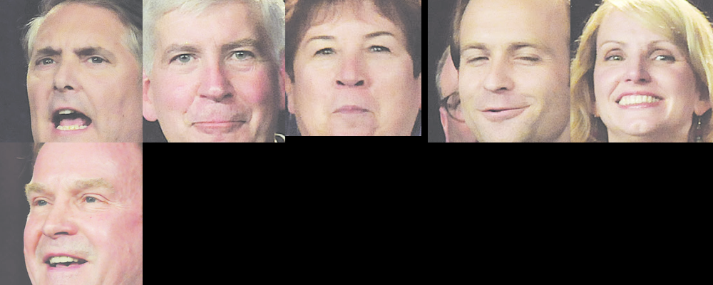

```
Results found in a-1.png
```

[figure not shown]

```
Results found in a-10.png
But there were not faces in that file!
Results found in a-2.png
```

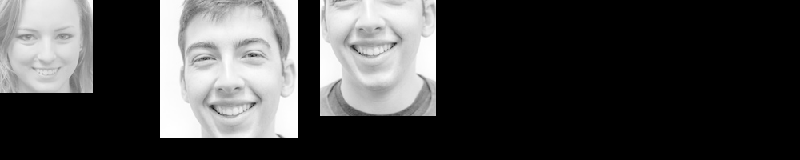

```
Results found in a-3.png
```

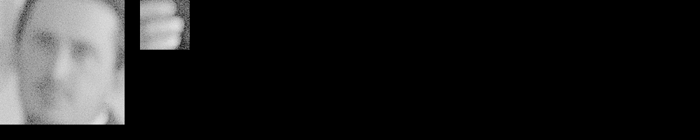

```
Results found in a-5.png
```

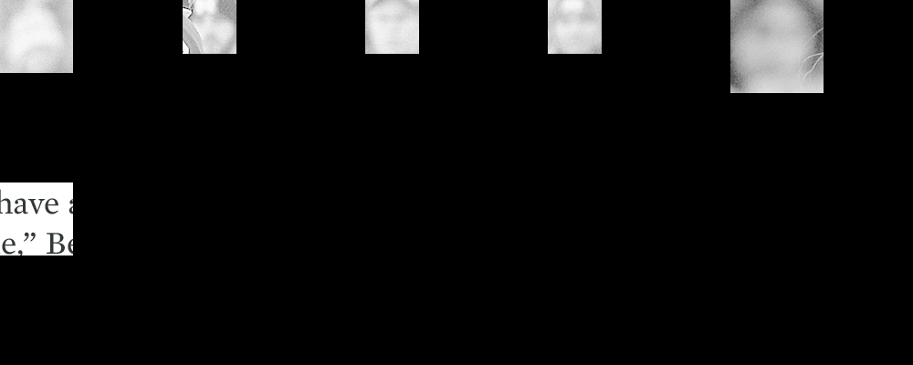

```
Results found in a-8.png
```

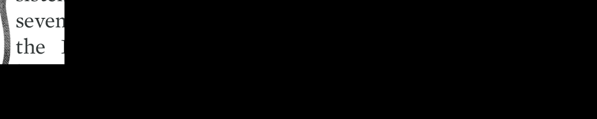

```
Results found in a-9.png
```

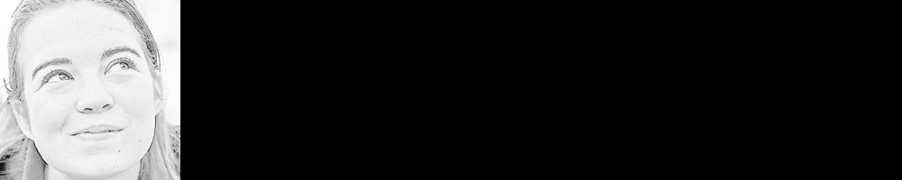

```
Search complete.
```

```python
text = ""
print("Beginning word search program")
text = input("Enter a keyword to search for (enter \"exit\" to close: ")

while text.lower() != "exit":
    print("Searching for {}".format(text))
    text = text.lower()

    for img in Image_list:
        if text in img['text']:
            print("Results found in {}".format(img['name']))

            if len(img['faces']) == 0: print("But there were not faces in that file!")
            else: display(contactSheetConstructor(img['faces']))

    print("Search complete.")

    text = input("Enter a keyword to search for (enter \"exit\" to close: ")

print("Program exiting")
```